# Forgobike Exploration Presentation

## by

## Fatimah Ajoke Abudu Olaleye

## Investigation Overview

For the presentation, I focused on telling a story behind higher ride duration, with a look at different categorical variables like user types, gender, days, and so on. Lastly, I did some comparison between the two cities, San Francisco and New York bike rides datasets.

## Dataset Overview

This data set includes information about individual rides made for February, 2019 in a bike-sharing system covering the greater San Francisco Bay area and New York city.These bike share systems, with hundreds of stations and thousands of bikes across both cities. It’s a fun, affordable and convenient way to get around.

## Distribution of ride duration

Plotted on a log scale, the distribution appears to be unimodal, with a lot of bike rides at the lower duration, lying less than 5000, with its peak between 500 and 1000.

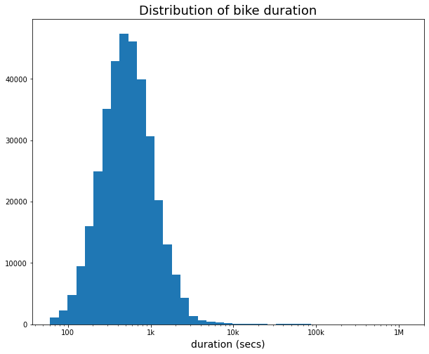

## Distribution of overall ages

The age distribution plotted on a normal scale, appears to be skewed to the right with concentration of ages between 25 to 40 from both city datasets.

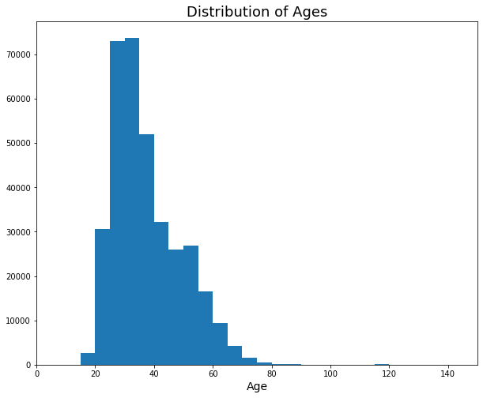

## Which of day of week have most trips corresponding to user type?

Thursday being the highest day trip taken. In this case, we have a better insight based on user type classification. Subscriber users appears to be highest on Thursdays, followed by Tuesday and Friday. Saturday and Sunday were the lowest days, but Wednesday appears to be the lowest for customer users.

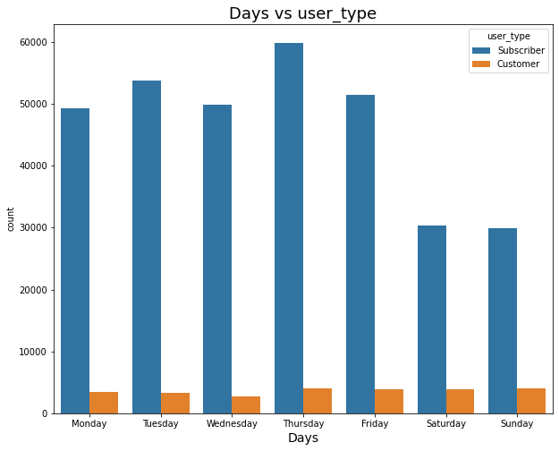

## Which of day of week have most trips corresponding to gender?

Male members appear to have the highest ride on Thursdays with lowest on weekends.

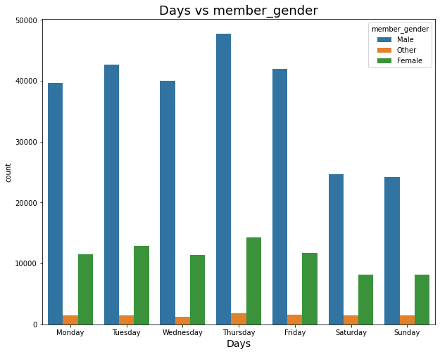

## Comparison of New York and San Francisco duration based on User type?

More subscribers than customers, it appears customers have the highest duration on Monday, Tuesday, and Thursday. Except for Wednesday and Friday with duration by subscribers. The user type tends to be slightly close on Saturday duration.

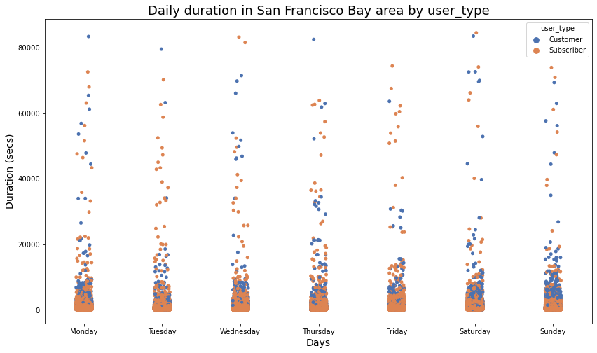

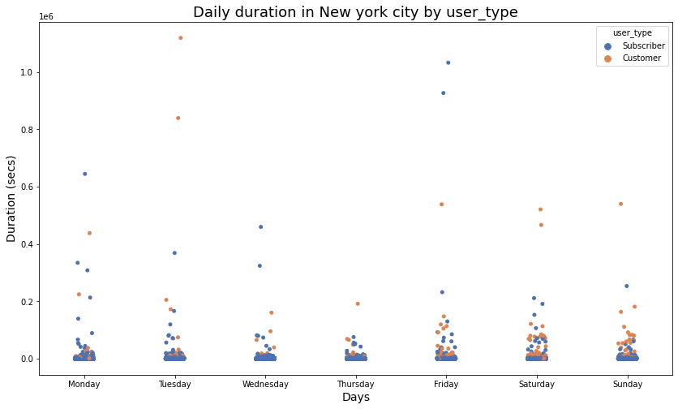

## Comparison of New York and San Francisco duration based on gender?

More bike riding in San Francisco than New York, we have more male engagement than females, with male members having more duration than female.

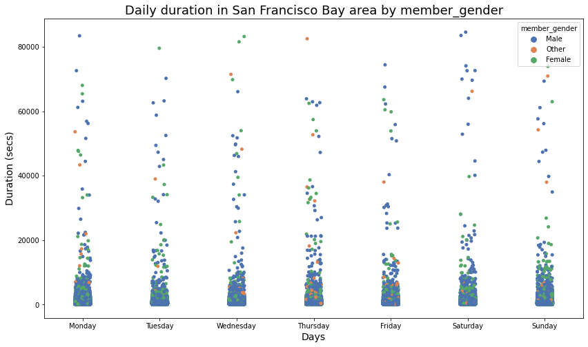

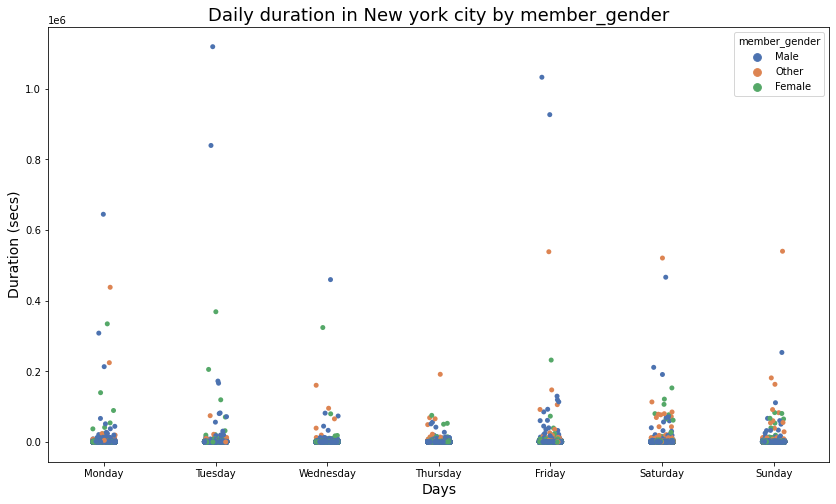